# Group Assignment: How Certain Is Our Tree Biomass Estimate?

Monte Carlo error propagation from field measurements to stand-level biomass

Published

September 29, 2026

# Overview

Trees store carbon, and carbon markets, national inventories and urban greening policies all need **estimates of woody biomass**. These estimates are never measured directly. They are *predicted* from field measurements of diameter and height using allometric models, and every step in that chain adds error.

In this assignment your group will:

1. **Read and discuss** a paper on biomass error propagation, guided by seven questions (Part 1).
2. **Measure** the diameter and height of at least 20 trees on campus or in a nearby park, following a sampling design (Part 2).
3. **Estimate** the stand-level above-ground biomass (AGB) and its uncertainty. You will use Monte Carlo error propagation with `BIOMASS::AGBmonteCarlo()` and extend it with a bootstrap for sampling error (Part 3).
4. **Present** your field work, results and interpretation (Part 4).

**Paper:** Yanai, R.D., Battles, J.J., Richardson, A.D., Blodgett, C.A., Wood, D.M. & Rastetter, E.B. (2010). Estimating uncertainty in ecosystem budget calculations. *Ecosystems* 13: 239–248. https://doi.org/10.1007/s10021-010-9315-8. The paper is open access; a free PDF is also available from the authors’ QUEST project (https://www.esf.edu/quest/documents/Yanaietal.2010.EstimatinguncertaintyinBiomass.pdf).

The paper estimates the *nitrogen* content of trees, but it gets there by first estimating tree height and biomass with allometric equations. Its lessons about biomass uncertainty apply directly to this assignment. You can ignore the nitrogen step (Eq. 3): in our analysis the chain stops at biomass.

## Learning outcomes

After this assignment you can:

- identify the error sources in a biomass prediction chain and classify them as random or systematic;
- explain why Monte Carlo methods are used to propagate errors through non-linear models;
- design and carry out a small field inventory, including a protocol for estimating your own measurement error;
- use `BIOMASS::AGBmonteCarlo()` to propagate measurement, wood density and allometric model errors to the stand level;
- combine propagated error with sampling error, and build an error budget;
- communicate an uncertain estimate honestly and clearly.

## Organisation

| Group size | 3–4 students |
| --- | --- |
| Prerequisite | Self-study module *Monte Carlo Methods in R* |
| R packages | `BIOMASS` (≥ 2.2) |

| Day | Activity | Deliverable |
| --- | --- | --- |
| Tue/Wed | Read the paper individually; group discussion | Discussion notes (Part 1) |
| Wed/Thu | Plan the design; practise the analysis on the practice data | Field plan (half a page) |
| Thu/Fri | Field work (about half a day) | Data file (`.csv`) |
| Fri | Analysis | Quarto/R script |
| Tue Oct 6 | Presentation (12 min + 5 min questions) | Slides + script + data |

# 1 Part 1 – Reading and discussing the paper

Each group member first reads the paper **individually**. Then meet as a group (about 2 h) and discuss the questions below. Hand in concise group answers of 1–2 pages in total. Where helpful, support your answers with a sketch, an equation or a few lines of pseudocode.

**NoteDiscussion questions**

**Q1 – Why Monte Carlo?** The authors argue that analytical (Gaussian) error propagation is “problematic” when the equations are non-linear or the coefficients of variation are high (> 30 %).

- Explain in your own words why a method based on partial derivatives (the slope of the function) fails for a strongly non-linear function with a large input uncertainty.
- Optionally: you can demonstrate this in R. Let $x \sim N(\mu = 3, \sigma)$ and $y = e^{x}$. Compare the first-order approximation $\text{SD}(y) \approx e^{\mu}\sigma$ with a Monte Carlo estimate, for $\sigma = 0.1$ and $\sigma = 0.5$. What happens to the *mean* of $y$?

**Q2 – The flowchart applied to *our* study.** Redraw Figure 1 of the paper for the analysis you will do in Part 3: measured DBH and height, wood density from a database, the Chave et al. (2014) biomass equation, and several plots.

- For every random number in your flowchart, state whether it is drawn once per **tree**, once per **species**, once per **plot**, or once per **iteration** (shared by all trees).
- The authors found 100 iterations sufficient. How can you check, for your own analysis, whether the number of iterations is sufficient (see their Figure 2)?

**Q3 – A common mistake: independent or shared errors?** The authors write that “a common mistake is to apply parameter uncertainty independently for each observation in the data set”.

- Explain why the diameter measurement error is drawn independently for each tree, while the error of the height and biomass equations is drawn once per iteration and applied to *all* trees of a species.
- Predict how the standard deviation of a stand total grows with the number of trees $n$ in each case. Check your prediction with a small R simulation: sum $n$ trees of 1 Mg each with a 20 % error that is either independent per tree or shared by all trees, for $n = 10, 100, 1000$.
- Why does a shared equation error matter much less when you *compare* two plots or sites than when you estimate a total?

**Q4 – Which error term?** The paper distinguishes the standard deviation of the regression $s_{y\cdot x}$ (Eq. 4), the error of the *mean* prediction $s_m$ (Eq. 5) and the error of an *individual* prediction $s_p$ (Eq. 6).

- Explain the difference between $s_m$ and $s_p$, and why both grow as $x$ moves away from the mean of the data used to fit the equation.
- Why does using $s_{y\cdot x}$ overestimate the uncertainty of the mean but underestimate the uncertainty of individual predictions?
- Which term is appropriate (a) for the total biomass of a stand and (b) for the carbon stored in one particular park tree, e.g. for a municipal tree valuation? What information must the authors of an allometric equation publish for you to compute $s_m$?

**Q5 – Adding up uncertainties and the number of plots.** The individual sources contribute 5 % (allometric equations), 3 % (N concentration), 6 % (plot variability) and 0.02 % (diameter measurement), yet the combined uncertainty is 8 %, not 14 %.

- Show with a calculation why 8 % is the expected answer. What rule do the authors use?
- With 5 plots the total uncertainty is 15 %; with 30–60 plots it levels off at about 7 %. Explain why adding plots cannot reduce the uncertainty below this level.
- The authors used 0.05-ha plots, like you will. What does their plot experiment (Table 1) suggest about the precision you can expect with your 4–6 plots? Which source will probably dominate your error budget?

**Q6 – Bias and errors that are *not* in the analysis.** The Monte Carlo mean (869 kg N/ha) is higher than the estimate calculated without error (847 kg N/ha).

- The authors list error sources they did *not* include: systematic errors, such as using an equation for another species (sugar maple for red maple) or at another site. Why can a Monte Carlo analysis of random errors not capture these?
- In Part 3 you will apply the *pantropical* Chave et al. (2014) equation to temperate park trees. Which of the omitted error types does this introduce, and how could you get an idea of its size?

**Q7 – What should be improved?** The authors note that the Monte Carlo analysis shows “which measurements should be improved”. Branches, for example, contribute most because they combine a high equation uncertainty with a large share of the total.

- Explain why the contribution of an error source to the *total* is not the same as the uncertainty of that source by itself.
- Suppose you have one extra field day. Would you spend it on more plots, more precise height measurements, or identifying the species of unidentified trees? Argue using the logic of the paper; you will test your answer with your own error budget in Part 3.
- The paper also describes how to test a *difference* between two sites with Monte Carlo (the proportion of iterations with a significant $t$-test). Describe how you would use this to compare your campus with a nearby park.

# 2 Part 2 – Field work

## 2.1 Sampling design

Your “stand” is a clearly delimited green area: part of the campus, a park, or a wood lot. Define its boundary and area (in ha) on a map, e.g. with OpenStreetMap or a GIS.

Use **fixed-area circular plots**:

- **Plot size.** Radius 12.62 m (area 500 m² = 0.05 ha). In sparse park settings a radius of 17.84 m (0.1 ha) may be needed.
- **Plot locations.** Place **at least 4 plots** at *random* or *systematic* (grid) points within the stand. Choose the points on the map **before** going into the field. Do not choose “nice-looking” spots on site; think about why, in light of Q5.
- **Trees to measure.** Measure **every** tree with its stem centre inside the plot and DBH ≥ 10 cm.
- **Minimum sample.** You need **at least 20 trees in total**. If you have fewer, add plots at new random points. Do not enlarge the existing plots.

**Tip**

If trees in your stand are too sparse for plots, you may instead measure **all** trees in a small, mapped stand (a census). In that case sampling error is zero by design, but you must discuss how representative your stand is of the larger area.

## 2.2 Measurements

For each tree record:

| Variable | How | Unit |
| --- | --- | --- |
| `plot`, `tree_id` | plot code; tree number within the plot | – |
| `genus`, `species` | identify in the field; use an app (e.g. ObsIdentify, PlantNet) if needed and check it | – |
| `dbh` | diameter at 1.3 m with a diameter tape, or circumference / π | cm |
| `h` | total height with a clinometer, hypsometer or smartphone app (tangent method, see below) | m |
| `lon`, `lat` | plot centre (GPS/phone) | decimal degrees |
| `notes` | multi-stemmed, leaning, damaged, measured on the slope side, … | – |

**Tangent method for height.** Stand at a horizontal distance $L$ from the tree where you can see both the top and the base. Measure the angle to the top ($\alpha_t$) and to the base ($\alpha_b$; negative if below eye level). Then

$$H = L\,\bigl(\tan\alpha_t - \tan\alpha_b\bigr).$$

For good precision, stand at a distance of about 1–1.5 × the tree height.

## 2.3 Repeat measurements (required)

To estimate **your own measurement error**, a *second* group member measures the DBH and height of **every tree** again, independently and without looking at the first value. Record both values (`dbh_1`, `dbh_2`, `h_1`, `h_2`). In Part 3 you will use these pairs to estimate the standard deviation of the measurement error that goes into `AGBmonteCarlo()`.

## 2.4 Data sheet

Enter the data in a CSV file with exactly these columns (one row per tree):

```
plot,tree_id,genus,species,dbh_1,dbh_2,h_1,h_2,lon,lat,notes
P1,1,Quercus,robur,45.3,45.8,21.5,23.0,4.9551,52.3551,
P1,2,Tilia,cordata,31.2,31.0,17.0,16.5,4.9551,52.3551,leaning
```

For plots, also record in a separate file: `plot`, `radius_m`, `lon`, `lat`, `date`, `observers`.

**WarningSafety and permission**

- Work at least in pairs.
- Do not climb trees and do not damage bark.
- Stay away from trees with dead branches overhead in windy weather.

# 3 Part 3 – Analysis

The code below runs on **simulated practice data** so you can develop your script *before* the field work. Afterwards, replace the practice data with your own file (Section 3.2). Everything else should run unchanged.

## 3.1 Practice data

```r
# Simulated park: 5 plots of 0.05 ha, typical Dutch park species
sim_park <- function(n_plots = 5, radius = 12.62) {
  spp <- data.frame(
    genus   = c("Quercus", "Fagus", "Tilia", "Acer", "Fraxinus",
                "Platanus", "Aesculus", "Betula"),
    species = c("robur", "sylvatica", "cordata", "pseudoplatanus", "excelsior",
                "x hispanica", "hippocastanum", "pendula"))
  n_per_plot <- rpois(n_plots, 4) + 2
  out <- do.call(rbind, lapply(seq_len(n_plots), function(p) {
    k <- n_per_plot[p]
    s <- spp[sample(nrow(spp), k, replace = TRUE), ]
    dbh <- round(10 + rlnorm(k, log(25), 0.6), 1)
    h <- 1.3 + 32 * (1 - exp(-0.035 * dbh)) * rlnorm(k, 0, 0.12)
    data.frame(plot = paste0("P", p), tree_id = seq_len(k), s,
               dbh_1 = dbh, dbh_2 = round(dbh + rnorm(k, 0, 0.6), 1),
               h_1 = round(h + rnorm(k, 0, 1.2), 1),
               h_2 = round(h + rnorm(k, 0, 1.2), 1))
  }))
  rownames(out) <- NULL
  out
}
trees <- sim_park()
plots <- data.frame(plot = unique(trees$plot), radius_m = 12.62)
head(trees)
```

```
  plot tree_id    genus        species dbh_1 dbh_2  h_1  h_2
1   P1       1     Acer pseudoplatanus  54.0  53.7 27.9 30.4
2   P1       2  Quercus          robur  38.3  38.4 33.5 33.6
3   P1       3 Platanus    x hispanica  32.1  31.7 25.5 22.6
4   P1       4    Tilia        cordata  25.1  25.4 18.1 20.1
5   P1       5 Aesculus  hippocastanum  22.4  22.1 18.4 21.8
6   P1       6 Fraxinus      excelsior  22.7  23.8 22.3 20.4
```

```r
nrow(trees)
```

```
[1] 35
```

## 3.2 Using your own data

```r
trees <- read.csv("trees.csv")
plots <- read.csv("plots.csv")
```

## 3.3 Step 1 – Explore and check the data

```r
library(BIOMASS)

trees$dbh <- (trees$dbh_1 + trees$dbh_2) / 2   # mean of the two measurements
trees$h   <- (trees$h_1 + trees$h_2) / 2

summary(trees[, c("dbh", "h")])
```

```
      dbh              h
 Min.   :18.15   Min.   :14.65
 1st Qu.:23.25   1st Qu.:18.45
 Median :30.00   Median :21.05
 Mean   :34.65   Mean   :22.70
 3rd Qu.:42.67   3rd Qu.:25.12
 Max.   :84.45   Max.   :36.80
```

```r
table(trees$plot)
```

```
P1 P2 P3 P4 P5
 7  6  8 10  4
```

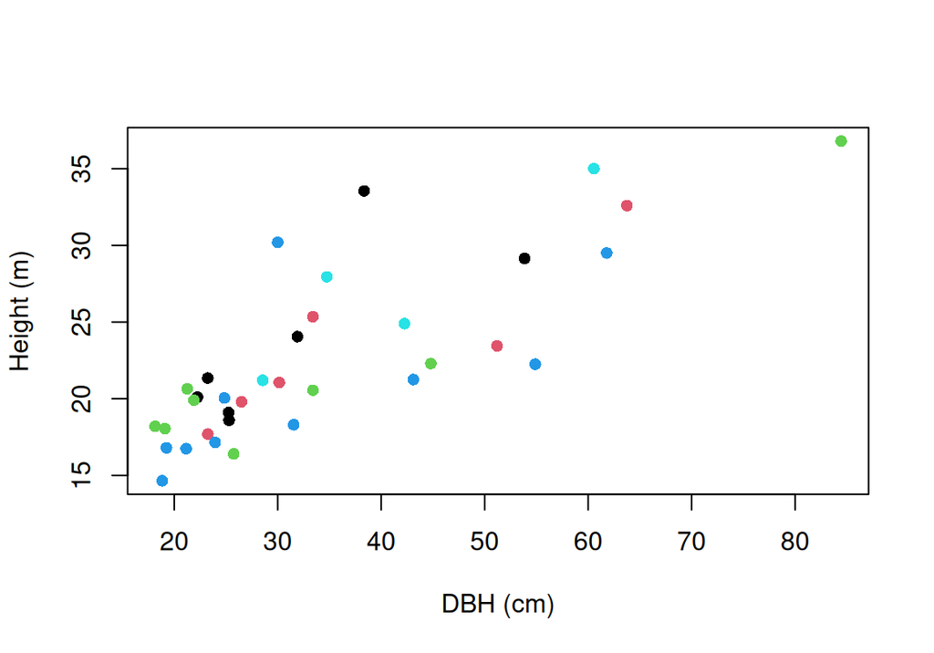

```r
plot(h ~ dbh, data = trees, pch = 16, col = factor(trees$plot),
     xlab = "DBH (cm)", ylab = "Height (m)")
```

Check for typing errors, e.g. a DBH of 453 instead of 45.3. Look for outliers in the height–diameter plot and go back to your field notes to explain them.

## 3.4 Step 2 – Measurement error from repeat measurements

If two independent measurements $x_1, x_2$ of the same tree each have error SD $\sigma$, then $\text{Var}(x_1 - x_2) = 2\sigma^2$, so $\hat\sigma = \text{sd}(x_1 - x_2)/\sqrt{2}$.

```r
sd_dbh <- sd(trees$dbh_1 - trees$dbh_2) / sqrt(2)
sd_h   <- sd(trees$h_1 - trees$h_2) / sqrt(2)
c(sd_dbh = sd_dbh, sd_h = sd_h)
```

```
   sd_dbh      sd_h
0.4002835 1.4990389
```

**Note**

These are the errors of a *single* measurement. You use the *mean* of two measurements, so its error SD is smaller by a factor $\sqrt{2}$. Decide, and justify in your presentation, which value to pass to `AGBmonteCarlo()`. Also consider whether the error grows with tree size: plot $|x_1 - x_2|$ against $\bar{x}$.

## 3.5 Step 3 – Wood density

`getWoodDensity()` looks up wood density (g/cm³) in the Global Wood Density Database, at species, genus or family level. It also returns an error (`sdWD`) that reflects the variability *within* that taxonomic level.

```r
wd <- getWoodDensity(genus = trees$genus, species = trees$species,
                     region = "Europe")
trees$wd    <- wd$meanWD
trees$sd_wd <- wd$sdWD
table(wd$levelWD)   # at which taxonomic level was WD found?
```

```
  genus species
      3      32
```

## 3.6 Step 4 – Point estimate

`computeAGB()` applies Chave et al. (2014, Eq. 4) and returns AGB per tree in **Mg** (tonnes):

$$\text{AGB} = 0.0673 \times (\rho D^2 H)^{0.976}$$

```r
trees$agb <- computeAGB(D = trees$dbh, WD = trees$wd, H = trees$h)

plot_area_ha <- pi * plots$radius_m^2 / 1e4
names(plot_area_ha) <- plots$plot

agb_plot <- tapply(trees$agb, trees$plot, sum) / plot_area_ha[names(table(trees$plot))]
round(agb_plot, 1)   # Mg/ha per plot
```

```
   P1    P2    P3    P4    P5
111.9 125.3 202.3 178.9 105.5
```

```r
total_area <- sum(plot_area_ha)
agb_ha <- sum(trees$agb) / total_area
round(agb_ha, 1)     # stand estimate, Mg/ha
```

```
[1] 144.8
```

## 3.7 Step 5 – Monte Carlo error propagation

**How do the error sources of Yanai et al. (2010) map onto our analysis?**

| Error source | Yanai et al. (2010) | In this assignment |
| --- | --- | --- |
| Diameter measurement | SD 0.05 cm, independent per tree | `Dpropag`: your own estimate from repeat measurements (Step 2), independent per tree |
| Tree height | predicted from DBH with an equation; error shared by all trees of a species | measured; `errH` is a *measurement* error, independent per tree (with `HDmodel =` it becomes a model error, see extension a) |
| Wood density | not needed (species-specific equations) | `errWD`: independent per tree |
| Biomass equation | error of the mean prediction ($s_m$), shared by all trees of a species | `AGBmonteCarlo()`: one draw of the Chave et al. (2014) parameters per iteration, shared by all trees, plus a residual error per tree |
| Tissue N concentration | shared per species and tissue | not applicable (we stop at biomass) |
| Plot variability (sampling) | normal draw from mean and SE of the plot totals | bootstrap over plots (Step 7) |
| Systematic errors (other species, other site, back-transformation) | not included | not included; see Q6 and extension b |

`AGBmonteCarlo()` propagates four error sources. In each of `n` iterations it:

1. adds random error to each tree’s **diameter** (`Dpropag`, SD in cm);
2. draws each tree’s **wood density** from a normal distribution with SD `errWD`;
3. draws each tree’s **height** with SD `errH`;
4. draws **one** parameter vector of the Chave et al. (2014) model from its Bayesian posterior and applies it to *all* trees (a systematic error). It then adds the model’s residual error to each tree.

The output `AGB_simu` is a matrix with trees in rows and iterations in columns.

```r
mc <- AGBmonteCarlo(D = trees$dbh, WD = trees$wd, errWD = trees$sd_wd,
                    H = trees$h, errH = sd_h, Dpropag = sd_dbh, n = 1000)
str(mc[1:4])
```

```
List of 4
 $ meanAGB       : num 36.4
 $ medAGB        : num 36
 $ sdAGB         : num 4.04
 $ credibilityAGB: Named num [1:2] 29.4 45.1
  ..- attr(*, "names")= chr [1:2] "2.5%" "97.5%"
```

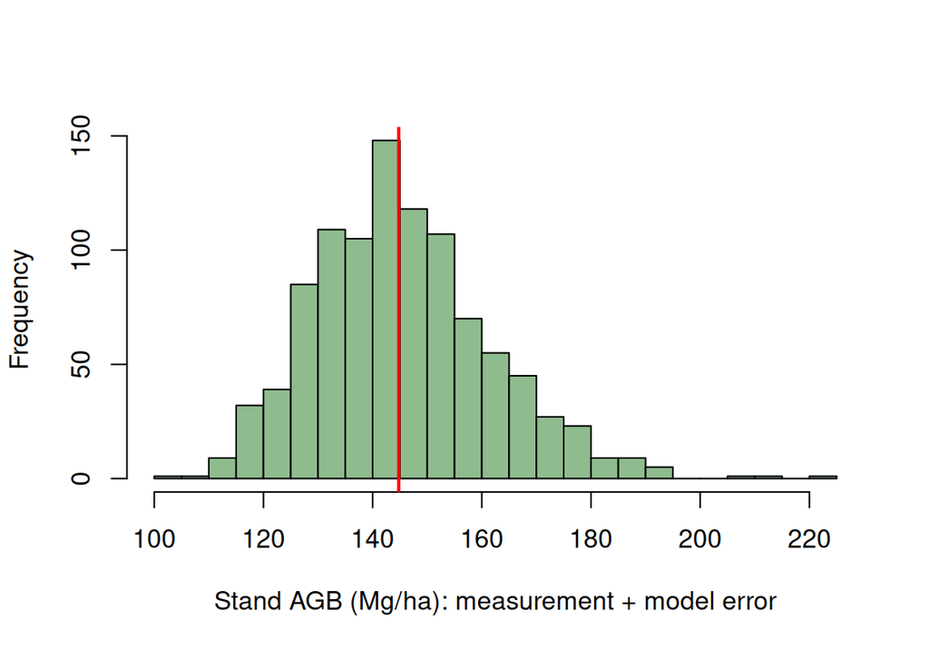

```r
# Stand-level AGB (Mg/ha) in each Monte Carlo iteration
agb_ha_mc <- colSums(mc$AGB_simu) / total_area

hist(agb_ha_mc, breaks = 40, col = "darkseagreen", main = "",
     xlab = "Stand AGB (Mg/ha): measurement + model error")
abline(v = agb_ha, col = "red", lwd = 2)
```

```r
quantile(agb_ha_mc, c(0.025, 0.5, 0.975))
```

```
    2.5%      50%    97.5%
117.6421 143.9598 180.1250
```

## 3.8 Step 6 – Error budget

Which error source contributes most? Switch the sources off one at a time (set their SD to 0) and compare the resulting SDs. The allometric model error cannot be switched off in `AGBmonteCarlo()`, so the run with all other sources set to zero shows the *model-only* error.

```r
run_mc <- function(errWD = trees$sd_wd, errH = sd_h, Dpropag = sd_dbh) {
  r <- AGBmonteCarlo(D = trees$dbh, WD = trees$wd, errWD = errWD,
                     H = trees$h, errH = errH, Dpropag = Dpropag, n = 1000)
  sd(colSums(r$AGB_simu) / total_area)
}
zero <- rep(0, nrow(trees))

budget <- c(
  "all sources"           = run_mc(),
  "without DBH error"     = run_mc(Dpropag = 0),
  "without height error"  = run_mc(errH = 0),
  "without WD error"      = run_mc(errWD = zero),
  "model error only"      = run_mc(errWD = zero, errH = 0, Dpropag = 0))
round(budget, 2)   # SD of stand AGB (Mg/ha)
```

```
         all sources    without DBH error without height error
               16.34                15.69                15.85
    without WD error     model error only
               15.24                14.77
```

**Note**

Monte Carlo SDs vary a little from run to run. Before interpreting small differences, repeat the budget a few times or compare with its Monte Carlo error. Because variances (not SDs) add for independent sources, compare **variances** when you express each source as a percentage of the total.

## 3.9 Step 7 – Adding sampling error

`AGBmonteCarlo()` treats your trees as the complete stand. If the plots are a *sample*, part of the uncertainty comes from *which* plots you happened to measure (Q5). Combine both sources in a nested Monte Carlo:

- in every iteration, take the per-plot AGB from **one** column of `AGB_simu` (measurement + model error);
- then **bootstrap the plots** (resample plots with replacement) and compute the mean AGB per ha.

```r
plot_ids <- names(plot_area_ha)
agb_plot_mc <- sapply(plot_ids, function(p) {
  colSums(mc$AGB_simu[trees$plot == p, , drop = FALSE]) / plot_area_ha[p]
})   # iterations x plots, Mg/ha

total_mc <- apply(agb_plot_mc, 1, function(x) mean(sample(x, replace = TRUE)))

sampling_only <- replicate(1000, mean(sample(agb_plot, replace = TRUE)))

rbind(
  "measurement + model" = quantile(agb_ha_mc, c(0.025, 0.5, 0.975)),
  "sampling only"       = quantile(sampling_only, c(0.025, 0.5, 0.975)),
  "combined"            = quantile(total_mc, c(0.025, 0.5, 0.975)))
```

```
                        2.5%      50%    97.5%
measurement + model 117.6421 143.9598 180.1250
sampling only       112.0113 143.4990 178.2736
combined            100.7179 141.0437 204.8483
```

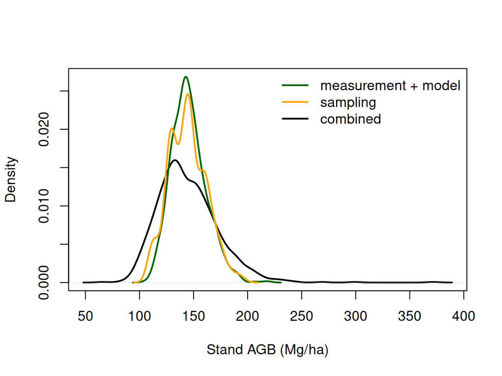

```r
d_mm <- density(agb_ha_mc); d_s <- density(sampling_only); d_t <- density(total_mc)
plot(d_t, main = "", xlab = "Stand AGB (Mg/ha)", lwd = 2,
     ylim = c(0, max(d_mm$y, d_s$y, d_t$y)))
lines(d_mm, col = "darkgreen", lwd = 2)
lines(d_s, col = "orange", lwd = 2)
legend("topright", bty = "n", lwd = 2, col = c("darkgreen", "orange", "black"),
       legend = c("measurement + model", "sampling", "combined"))
```

**Warning**

With only 4–6 plots, the bootstrap underestimates the sampling variance and gives rough intervals. Discuss this limitation, and compare the result with the classical standard error $s/\sqrt{k}$ of the plot means ($k$ plots).

## 3.10 Step 8 – Optional extensions (choose at least one)

1. **Height–diameter model.** Instead of measured heights, fit a local height–diameter model (`modelHD()`) and pass it as `HDmodel =` to `AGBmonteCarlo()`. How does the uncertainty change? When would this be the better strategy?
2. **Model choice (structural uncertainty).** Find a *temperate* allometric equation for one or more of your species, e.g. in Zianis et al. (2005), *Biomass and stem volume equations for tree species in Europe*. Compare the resulting AGB with the pantropical estimate. Is the difference within the Monte Carlo interval? Relate your answer to Q6 (systematic errors).
3. **Carbon and CO₂.** Use `Carbon = TRUE` to propagate the uncertainty in the carbon fraction, and convert to CO₂-equivalents (× 44/12). Present the result per ha and for the whole stand area.
4. **Design question.** Use your data to simulate the precision you would get with 10 or 20 plots, or with a better height instrument (smaller `errH`). Where should the next field day be spent (Q7)?

# 4 Part 4 – Presentation

Each group gives a **12-minute presentation** followed by 5 minutes of questions. The slides must include:

1. **Question and site.** Why estimate biomass here? Include a map of the stand and the plot locations.
2. **Methods.** Sampling design, measurement protocol, instruments, and the estimated measurement errors (Step 2).
3. **Field data.** Number of trees and species, and a DBH–height plot. Include one photo of the team at work.
4. **Point estimate.** AGB per plot and for the stand (Mg/ha, and Mg for the whole area).
5. **Monte Carlo uncertainty.** Histogram of the stand AGB distribution, with the 95 % interval.
6. **Error budget.** A bar chart of the contributions of each error source, including sampling error (Steps 6–7).
7. **Link to the paper.** Two or three key points from your Part 1 discussion, compared with your own findings. Do you also find that plot variability dominates, as at Hubbard Brook?
8. **Limitations and recommendations.** What would you do differently with twice the time (Q7)?

Hand in the slides, the R/Quarto script, and the data files. The script must reproduce every number and figure in the presentation (use `set.seed()`).

# 5 Assessment

| Component | Weight | Criteria |
| --- | --- | --- |
| Discussion notes (Part 1) | 25 % | Correct and critical use of the paper; clear reasoning; Q1/Q3 simulations and Q5 calculation are correct |
| Field work & data (Part 2) | 20 % | Design followed and documented; ≥ 20 trees; repeat measurements; clean, well-documented data file |
| Analysis (Part 3) | 30 % | Correct use of `BIOMASS`; justified error inputs; error budget; sampling error included; reproducible script |
| Presentation (Part 4) | 25 % | Clear storyline; honest communication of uncertainty; good figures; answers to questions |

# References

- Chave, J. et al. (2014). Improved allometric models to estimate the aboveground biomass of tropical trees. *Global Change Biology* 20: 3177–3190. https://doi.org/10.1111/gcb.12629
- Réjou-Méchain, M., Tanguy, A., Piponiot, C., Chave, J. & Hérault, B. (2017). BIOMASS: an R package for estimating above-ground biomass and its uncertainty in tropical forests. *Methods in Ecology and Evolution* 8: 1163–1167. https://doi.org/10.1111/2041-210X.12753
- Yanai, R.D., Battles, J.J., Richardson, A.D., Blodgett, C.A., Wood, D.M. & Rastetter, E.B. (2010). Estimating uncertainty in ecosystem budget calculations. *Ecosystems* 13: 239–248. https://doi.org/10.1007/s10021-010-9315-8
- *Further reading:* Roxburgh, S.H. & Paul, K.I. (2025). Comprehensive propagation of errors for the prediction of woody biomass. *Methods in Ecology and Evolution* 16(1): 197–214. https://doi.org/10.1111/2041-210X.14471
- Zianis, D., Muukkonen, P., Mäkipää, R. & Mencuccini, M. (2005). Biomass and stem volume equations for tree species in Europe. *Silva Fennica Monographs* 4. https://doi.org/10.14214/sf.sfm4
- BIOMASS package documentation: https://umr-amap.github.io/BIOMASS/